# Biostat 212A Homework 3

Due Feb 18, 2025 @ 11:59PM

Author

Wenqiang Ge UID:106371961

Published

February 12, 2025

## 1 ISL Exercise 5.4.2 (10pts)

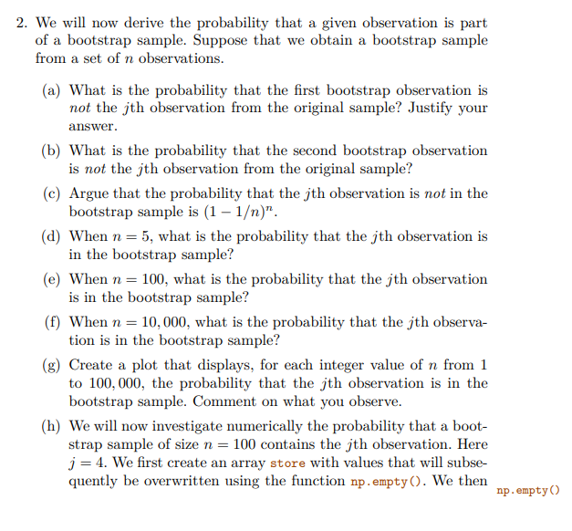

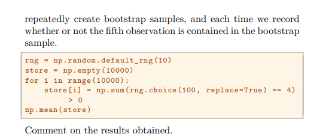

Solution:

(a) The first bootstrap sample is selected randomly from the set of $n$ observations, with replacement. The probability that the first sample is not the $j-th$ observation from the original sample is :

$P\ (first\ sample\ is\ not\ j\ )\ =\ \frac{n-1}{n}$

This is because there are $n−1$ other possible observations that could be selected out of the total $n$.

(b) The second bootstrap sample is selected randomly from the set of $n$ observations, with replacement. The probability that the first sample is not the $j-th$ observation from the original sample is :

$P\ (second\ sample\ is\ not\ j\ )\ =\ \frac{n-1}{n}$

It has the same probability of the first sample is not the $j-th$ observation.

(c) Since each observation is selected independently with replacement, the probability that the $j-th$ observation is not selected in any specific sample is $(1− \frac{1}{n})$. Therefore, the probability that the $j-th$ observation is not in the bootstrap sample is:

$P\ (\ j-th\ observation\ is\ not\ in\ sample\ )\ =\ (1\ -\frac{1}{n})^n$.

(d)The probability that the $j-th$ observation is included in the bootstrap sample when $n=5$:

$P\ (\ j-th\ observation\ is\ in\ sample\ )\ =\ 1- (\ 1-\frac{1}{5})^5 \ \approx\ 0.672$

(e)The probability that the $j-th$ observation is included in the bootstrap sample when $n=100$:

$P\ (\ j-th\ observation\ is\ in\ sample\ )\ =\ 1- (\ 1-\frac{1}{100})^{100} \ \approx\ 0.634$

(f)The probability that the $j-th$ observation is included in the bootstrap sample when $n=10,000$:

$P\ (\ j-th\ observation\ is\ in\ sample\ )\ =\ 1- (\ 1-\frac{1}{10,000})^{10,000} \ \approx\ 0.632$

(g)

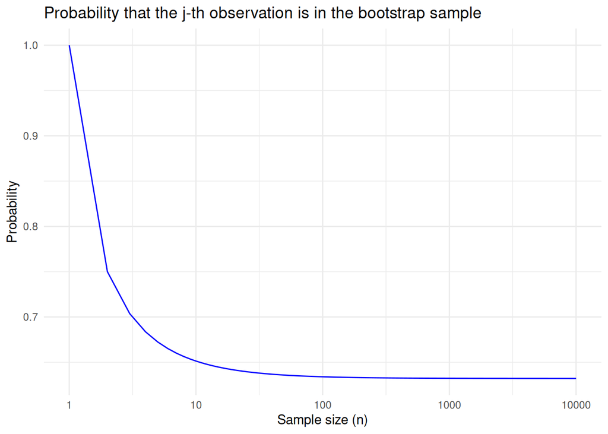

```r
library(ggplot2)

n_values <- 1:10000
probabilities <- 1 - (1 - 1/n_values)^n_values
data <- data.frame(n = n_values, probability = probabilities)

ggplot(data, aes(x = n, y = probability)) +
  geom_line(color = "blue") +
  scale_x_log10() +
  labs(x = "Sample size (n)",
       y = "Probability",
       title = "Probability that the j-th observation is in the bootstrap sample") +
  theme_minimal()
```

(h)

```r
set.seed(10)
n <- 100
num_simulations <- 10000

store <- numeric(num_simulations)

for (i in 1:num_simulations) {
  sample <- sample(1:n, n, replace = TRUE)
  store[i] <- sum(sample == 4) > 0
}

probability <- mean(store)
print(probability)
```

```
[1] 0.6279
```

The simulation result gives a probability of approximately 0.6279. This means, based on the 10,000 simulations, the 5th observation is included in about 62.79% of the bootstrap samples.

This probability shows how often the 5th observation appears in the bootstrap samples.Since bootstrap sampling is done with replacement, each observation has a chance of being repeated in each sample, and hence the probability reflects how likely it is for a specific observation (in this case, the 5th) to appear in a given sample.

## 2 ISL Exercise 5.4.9 (20pts)

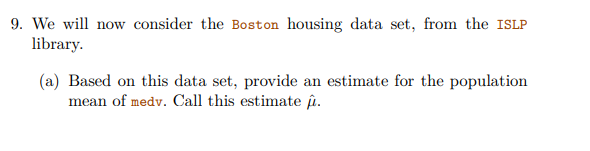

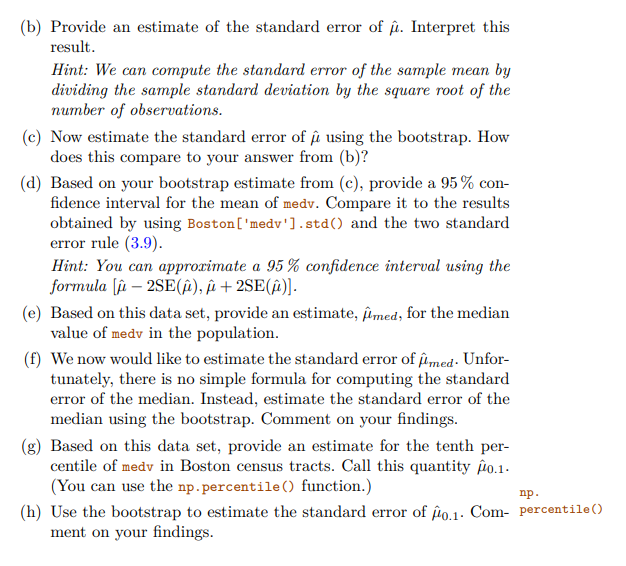

Solution:

(a)

```r
library(ISLR)
library(MASS)

data("Boston")
mu_hat <- mean(Boston$medv)
print(mu_hat)
```

```
[1] 22.53281
```

(b)

```r
# Calculate standard deviation of medv
s <- sd(Boston$medv)

# Calculate the number of observations
n <- length(Boston$medv)

# Calculate the standard error of the mean
SE_mu_hat <- s / sqrt(n)
print(SE_mu_hat)
```

```
[1] 0.4088611
```

(c)

```r
# Number of bootstrap samples
num_bootstrap <- 10000

# Set seed for reproducibility
set.seed(10)

# Create an empty vector to store the bootstrap sample means
bootstrap_means <- numeric(num_bootstrap)

# Perform bootstrap resampling
for (i in 1:num_bootstrap) {
  bootstrap_sample <- sample(Boston$medv, size = n, replace = TRUE)
  bootstrap_means[i] <- mean(bootstrap_sample)
}

# Estimate the standard error using the bootstrap
SE_bootstrap <- sd(bootstrap_means)
print(SE_bootstrap)
```

```
[1] 0.4070829
```

(d)

```r
# Use the results from part (c) to calculate the 95% confidence interval

# Calculate the sample mean
mu_hat <- mean(Boston$medv)

# Standard error from the bootstrap samples
SE_bootstrap <- sd(bootstrap_means)

# Confidence interval using bootstrap
CI_lower_bootstrap <- mu_hat - 2 * SE_bootstrap
CI_upper_bootstrap <- mu_hat + 2 * SE_bootstrap

cat("95% Confidence Interval from Bootstrap: [", CI_lower_bootstrap, ", ", CI_upper_bootstrap, "]\n")
```

```
95% Confidence Interval from Bootstrap: [ 21.71864 ,  23.34697 ]
```

```r
# Now, calculate the standard error using the sample's standard deviation
std_dev <- sd(Boston$medv)

# Confidence interval using the two standard error rule
CI_lower_sample <- mu_hat - 2 * SE_mu_hat
CI_upper_sample <- mu_hat + 2 * SE_mu_hat

cat("95% Confidence Interval from Sample Standard Error: [", CI_lower_sample, ", ", CI_upper_sample, "]\n")
```

```
95% Confidence Interval from Sample Standard Error: [ 21.71508 ,  23.35053 ]
```

(e)

```r
# Estimate the median of medv
mu_med_hat <- median(Boston$medv)
print(mu_med_hat)
```

```
[1] 21.2
```

(f)

```r
# Create an empty vector to store the bootstrap sample medians
bootstrap_medians <- numeric(num_bootstrap)

# Perform bootstrap resampling for median
for (i in 1:num_bootstrap) {
  bootstrap_sample <- sample(Boston$medv, size = n, replace = TRUE)
  bootstrap_medians[i] <- median(bootstrap_sample)
}

# Estimate the standard error of the median
SE_med_bootstrap <- sd(bootstrap_medians)/ sqrt(num_bootstrap)
print(SE_med_bootstrap)
```

```
[1] 0.003792189
```

(g)

```r
# Estimate the 10th percentile of medv
mu_hat_0.1 <- quantile(Boston$medv, 0.1)
print(mu_hat_0.1)
```

```
  10%
12.75
```

(h)

```r
# Number of bootstrap samples
num_bootstrap <- 10000

# Create an empty vector to store the bootstrap sample 10th percentiles
bootstrap_mu_hat_0.1 <- numeric(num_bootstrap)

# Perform bootstrap resampling for 10th percentile
for (i in 1:num_bootstrap) {
  bootstrap_sample <- sample(Boston$medv, size = length(Boston$medv), replace = TRUE)
  bootstrap_mu_hat_0.1[i] <- quantile(bootstrap_sample, 0.1)
}

# Estimate the standard error of the 10th percentile
SE_mu_hat_0.1 <- sd(bootstrap_mu_hat_0.1)
print(SE_mu_hat_0.1)
```

```
[1] 0.5037677
```

## 3 Least squares is MLE (10pts)

Show that in the case of linear model with Gaussian errors, maximum likelihood and least squares are the same thing, and $C_p$ and AIC are equivalent.

## 4 ISL Exercise 6.6.1 (10pts)

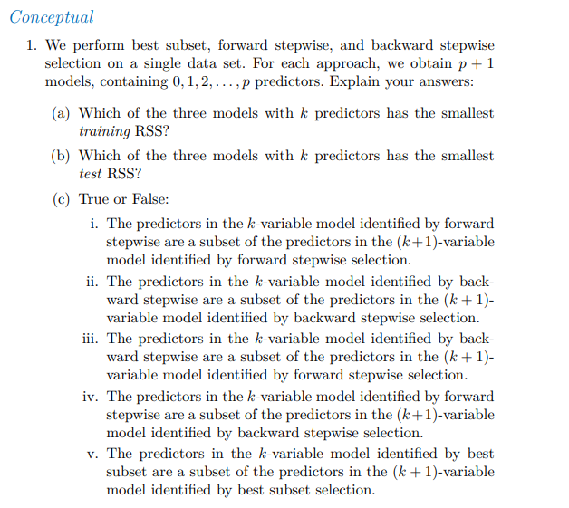

Solution:

(a) Best subset selection will yield the smallest training RSS.

(b) Forward stepwise selection will likely yield the smallest test RSS.

(c) i: True;

ii: False;

iii: False;

iv: True

v: True

## 5 ISL Exercise 6.6.3 (10pts)

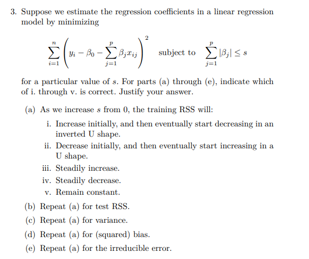

Solution:

(a) **i: Increase initially, and then eventually start decreasing in an inverted U shape.**

When $s$ is small (close to 0), the model will have fewer non-zero coefficients which leads to underfitting, and the training RSS will be relatively high.

As $s$ increases, the model can accommodate more predictors, so it fits the data better, and the training RSS starts to decrease.

As $s$ continues to increase, more coefficients are included, and the model may overfit the data. Eventually, the training RSS will start increasing again as the model becomes too complex.

(b) **ii. Decrease initially, and then eventually start increasing in a U shape.**

Training RSS follows an inverted U-shape, because increasing the number of predictors improves the fit to the training data initially, but eventually leads to overfitting.

Test RSS: The test RSS will likely follow a U-shape. Initially, as you increase $s$, the test RSS will decrease (since the model starts fitting the data better), but after a certain point, as the model overfits, the test RSS will start to increase.

(c) **ii. Decrease initially, and then eventually start increasing in a U shape.**

Variance refers to the variability of the model predictions across different datasets (e.g., in a cross-validation setting or in new datasets).

When $s=0$, the model is overly constrained and underfits, leading to higher variance. As we increase $s$, the model becomes more flexible and is able to fit the data better, which initially reduces variance. However, if $s$ increases too much and the model overfits, the variance will increase because the model becomes overly sensitive to the training data.

Bias is the difference between the expected model prediction and the true value.

When $s=0$, the model is highly constrained and underfits, which results in a high bias.

As $s$ increases, the model becomes more flexible and starts fitting the data better, reducing the bias.

If $s$ increases too much, the model starts to overfit, which means it fits the training data well but is less likely to generalize to new data, resulting in low bias.

Thus, squared bias will steadily decrease as $s$ increases because the model is able to fit the true underlying relationship better.

(e) **v. Remain constant.**

Irreducible error is the noise in the data that cannot be explained by the model. It is constant and does not depend on the complexity of the model.

## 6 ISL Exercise 6.6.4 (10pts)

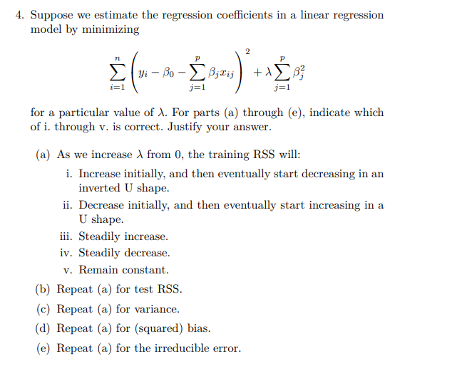

Solution:

(a) **i: Increase initially, and then eventually start decreasing in an inverted U shape.**

When $\lambda\ =\ 0$, there is no penalty term, so the objective function is just RSS. The model will likely overfit the data with more complex models, resulting in a very low training RSS.

As $\lambda$ increases, the penalty on the coefficients increases, which forces the coefficients to shrink towards zero, making the model simpler. The model will not fit the training data as perfectly, so the training RSS will initially increase.

As $\lambda$ continues to increase, the model will become increasingly constrained, and the coefficients will be forced to shrink more and more, making the model even simpler.

Eventually, the model will be too simple (potentially just a constant model), and the training RSS will start decreasing as it reduces the model complexity.

(b) **ii. Decrease initially, and then eventually start increasing in a U shape.**

When $\lambda\ =\ 0$, the model might overfit the data, and the test RSS will be relatively high.

As $\lambda$ increases, the model starts to generalize better by reducing overfitting. This will reduce the test RSS initially.

As $\lambda$ increases further, the model becomes too simple, and the test RSS may start increasing again, as it fails to capture the complexity of the data.

Variance refers to the variability of the model’s predictions.

When $\lambda\ =\ 0$, the model may have high variance because it fits the training data too well, capturing noise as if it were signal.

As $\lambda$ increases, the model is constrained, reducing its ability to fit the noise, and the variance of the predictions decreases.

As $\lambda$ increases too much, the model becomes too simple (potentially underfitting), but the variance would remain low because it is no longer sensitive to fluctuations in the data.

(d) **iii. Steadily increase.**

When $\lambda\ =\ 0$, the model has no penalty, and it is free to fit the data exactly (which could result in low bias for the training data but high variance).

As $\lambda$ increases, the model is forced to simplify, which increases bias because the model is less able to capture the true underlying relationship in the data.

As $\lambda$ increases too much, the bias continues to increase because the model becomes too simple and may underfit the data.

(e) **v. Remain constant.**

The irreducible error is the noise in the data that cannot be modeled or explained by the predictors. This error is constant and does not depend on the model or the value of $\lambda$.

## 7 ISL Exercise 6.6.5 (10pts)

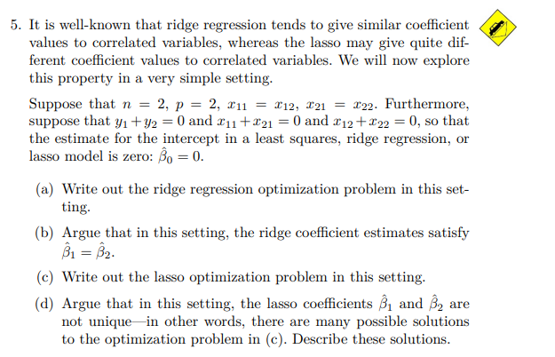

Solution:

## 8 ISL Exercise 6.6.11 (30pts)

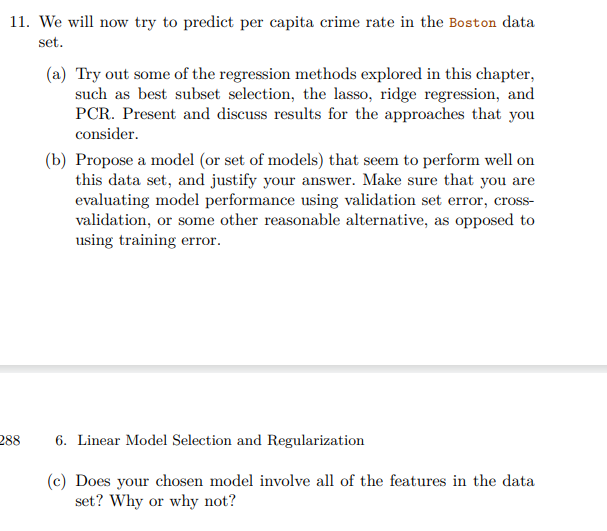

You must follow the [typical machine learning paradigm](https://ucla-biostat-212a.github.io/2024winter/slides/06-modelselection/workflow_lasso.html) to compare *at least* 3 methods: least squares, lasso, and ridge. Report final results as

| Method | CV RMSE | Test RMSE |  |
| --- | --- | --- | --- |
| LS |  |  |  |
| Ridge |  |  |  |
| Lasso |  |  |  |
| … |  |  |  |

Solution:

## 9 Bonus question (20pts)

Consider a linear regression, fit by least squares to a set of training data $(x_1, y_1), \ldots, (x_N, y_N)$ drawn at random from a population. Let $\hat \beta$ be the least squares estimate. Suppose we have some test data $(\tilde{x}_1, \tilde{y}_1), \ldots, (\tilde{x}_M, \tilde{y}_M)$ drawn at random from the same population as the training data. If $R_{\text{train}}(\beta) = \frac{1}{N} \sum_{i=1}^N (y_i - \beta^T x_i)^2$ and $R_{\text{test}}(\beta) = \frac{1}{M} \sum_{i=1}^M (\tilde{y}_i - \beta^T \tilde{x}_i)^2$. Show that
$$\operatorname{E}[R_{\text{train}}(\hat{\beta})] < \operatorname{E}[R_{\text{test}}(\hat{\beta})].$$